# Zillow project, Week 2, Flora Li

# Step one - Collecting data

This dataset is collected from kaggle zillow challenge.

# Step two - Exploring and preparing the data

# Import data

```r
train<-read.csv('train_property.csv',stringsAsFactors = F)
```

# extract trans_year, trans_month, trans_day

```r
train$txnyear <- sapply(strsplit(train$transactiondate, '-'), '[[', 1)
train$txnmonth <- sapply(strsplit(train$transactiondate, '-'), '[[', 2)
train$txnday <- sapply(strsplit(train$transactiondate, '-'), '[[', 3)
train$txn_weekday <- weekdays(as.Date(train$transactiondate))
```

## Rename the features in train dataset

```r
train <- plyr::rename(train,
                     c("parcelid"="id_parcel",
                       "transactiondate" = "trans_date",
                       "yearbuilt" = "build_year",
                       "basementsqft"="area_base_living",
                       "yardbuildingsqft17"="area_patio",
                       "yardbuildingsqft26"="area_shed",
                       "poolsizesum"="area_pool",
                       "lotsizesquarefeet"="area_lot",
                       "garagetotalsqft"="area_garage",
                       "finishedfloor1squarefeet" = "area_firstfloor_finished",
                       "calculatedfinishedsquarefeet" = "area_total_calc",
                       "finishedsquarefeet6" = "area_base",
                       "finishedsquarefeet12" = "area_live_finished",
                       "finishedsquarefeet13" = "area_liveperi_finished",
                       "finishedsquarefeet15" = "area_total_finished",
                       "finishedsquarefeet50" = "area_unknown",
                       "unitcnt" = "num_unit",
                       "numberofstories" = "num_story",
                       "roomcnt" = "num_room",
                       "bathroomcnt" = "num_bathroom",
                       "bedroomcnt" = "num_bedroom",
                       "calculatedbathnbr" = "num_bathroom_calc",
                       "fullbathcnt" = "num_bath",
                       "threequarterbathnbr" = "num_75_bath",
                       "fireplacecnt" = "num_fireplace",
                       "poolcnt" = "num_pool",
                       "garagecarcnt" = "num_garage",
                       "regionidcounty" = "region_county",
                       "regionidcity" = "region_city",
                       "regionidzip" = "region_zip",
                       "regionidneighborhood" = "region_neighbor",
                       "taxvaluedollarcnt" = "tax_total",
                       "structuretaxvaluedollarcnt" = "tax_building",
                       "landtaxvaluedollarcnt" = "tax_land",
                       "taxamount" = "tax_property",
                       "assessmentyear" = "tax_year",
                       "taxdelinquencyflag" = "tax_delinquency",
                       "taxdelinquencyyear" = "tax_delinquency_year",
                       "propertyzoningdesc" = "zoning_property",
                       "propertylandusetypeid" = "zoning_landuse",
                       "propertycountylandusecode" = "zoning_landuse_county",
                       "fireplaceflag" = "flag_fireplace",
                       "hashottuborspa" = "flag_tub",
                       "buildingqualitytypeid" = "quality",
                       "buildingclasstypeid" = "framing",
                       "typeconstructiontypeid" = "material",
                       "decktypeid" = "deck",
                       "storytypeid" = "story",
                       "heatingorsystemtypeid" = "heating",
                       "airconditioningtypeid" = "aircon",
                       "architecturalstyletypeid" = "architectural_style",
                       "pooltypeid10" = "flag_spa",
                       "pooltypeid2" = "flag_pool_spa",
                       "pooltypeid7" = "flag_pool_tub",
                       "fips"="county"))
```

## correct variable type

```r
# numerical variable
variable_numeric = c("area_firstfloor_finished",
                     "area_base", "area_base_living",
                     "area_garage",
                     "area_live_finished",
                     "area_liveperi_finished",
                     "area_lot",
                     "area_patio",
                     "area_pool",
                     "area_shed",
                     "area_total_calc",
                     "area_total_finished",
                     "area_unknown",
                     "tax_building",
                     "tax_land",
                     "tax_property",
                     "tax_total",
                     "latitude",
                     "longitude")
# discrete
variable_discrete = c("num_75_bath",
                      "num_bath",
                      "num_bathroom",
                      "num_bathroom_calc",
                      "num_bedroom",
                      "num_fireplace",
                      "num_garage",
                      "num_pool",
                      "num_room",
                      "num_story",
                      "num_unit")

variable_binary = c("flag_fireplace",
                    "flag_tub",
                    "flag_spa",
                    "flag_pool_spa",
                    "flag_pool_tub",
                    "tax_delinquency")

# categorical variable
variable_nominal = c("aircon",
                     "architectural_style",
                     "county",
                     "deck",
                     "framing",
                     "heating",
                     "id_parcel",
                     "material",
                     "region_city",
                     "region_county",
                     "region_neighbor",
                     "region_zip",
                     "story",
                     "zoning_landuse",
                     "zoning_landuse_county")
variable_ordinal = c("quality")

# date
variable_date = c("tax_year",
                  "build_year",
                  "tax_delinquency_year",
                  "trans_year",
                  "trans_month",
                  "trans_day",
                  "trans_date",
                  "trans_weekday")

# others
variable_unstruct = c("zoning_property")

# don't understand
variable_unknown = c('censustractandblock',
                     'rawcensustractandblock')
```

## Conversion

```r
train[train$flag_fireplace == "", "flag_fireplace"] = 0
train[train$flag_fireplace == "true", "flag_fireplace"] = 1
train[train$flag_tub == "", "flag_tub"] = 0
train[train$flag_tub == "true", "flag_tub"] = 1
train[train$tax_delinquency == "", "tax_delinquency"] = 0
train[train$tax_delinquency == "Y", "tax_delinquency"] = 1
# convert to numeric to double
train[,variable_numeric] = sapply(train[,variable_numeric], as.numeric)
# convert to discrete to int
train[,c(variable_discrete, variable_binary)] = sapply(train[,c(variable_discrete, variable_binary)], as.integer)
# convert to categorical to character
train[,c(variable_nominal, variable_ordinal)] = sapply(train[,c(variable_nominal, variable_ordinal)], as.character)
```

# Generate new features

## Date variables

### Transaction date

1. Transaction year

```r
table(train$txnyear)
```

```
##
##  2016
## 90275
```

There is only one year for the transaction.

2. Transaction month

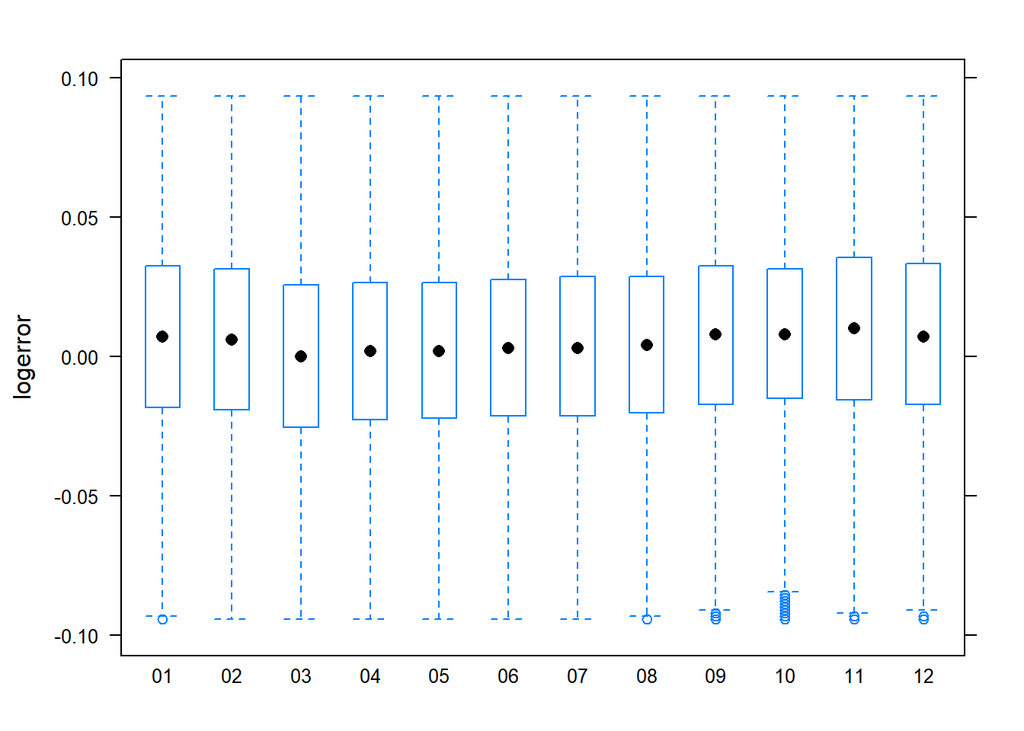

```r
library(lattice)
bwplot(logerror ~ txnmonth, data = subset(train, abs(logerror) < quantile(train$logerror,0.9)))
```

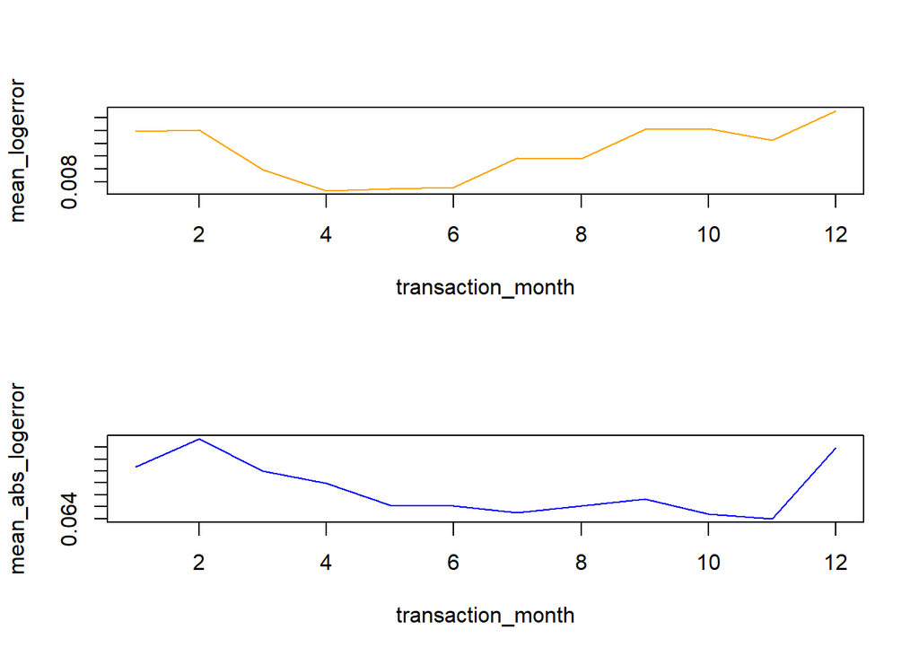

```r
err.month_txnmonth <- by(train, train$txnmonth, function(x) { return(mean(x$logerror))})
par(mfrow=c(2,1))
plot(names(err.month_txnmonth), err.month_txnmonth, type = 'l',xlab='transaction_month',ylab='mean_logerror',col='orange')
err.month_txnmonth1 <- by(train, train$txnmonth, function(x) { return(mean(abs(x$logerror)))})
plot(names(err.month_txnmonth1), err.month_txnmonth1, type = 'l',xlab='transaction_month',ylab='mean_abs_logerror', col='blue')
```

For both average logerror and absolute logerror, We can see that the Zestimate prediction tends to be less accurate at the beginning and end of the year.

3. Transaction day

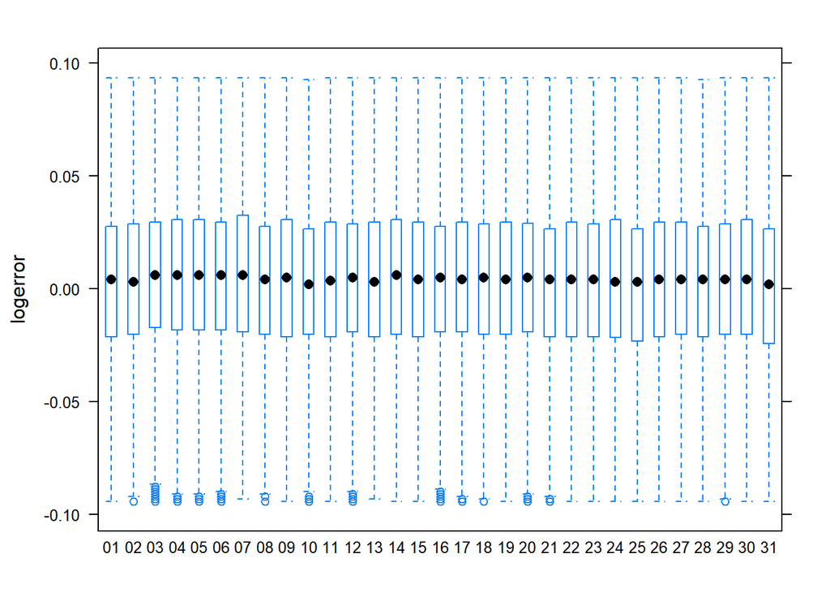

```r
bwplot(logerror ~ txnday, data = subset(train, abs(logerror) < quantile(train$logerror,0.9)))
```

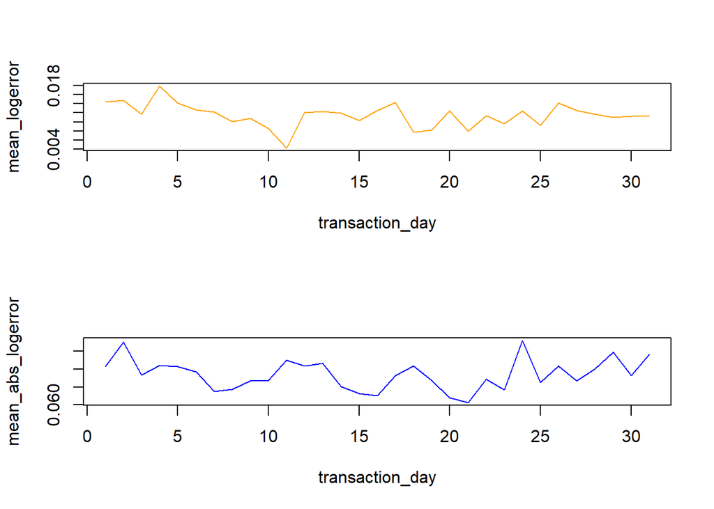

```r
err.day_txnday <- by(train, train$txnday, function(x) { return(mean(x$logerror))})
par(mfrow=c(2,1))
plot(names(err.day_txnday), err.day_txnday, type = 'l',xlab='transaction_day',ylab='mean_logerror',col='orange')
err.day_txnday1 <- by(train, train$txnday, function(x) { return(mean(abs(x$logerror)))})
plot(names(err.day_txnday1), err.day_txnday1, type = 'l',xlab='transaction_day',ylab='mean_abs_logerror', col='blue')
```

4. Transaction weekdays

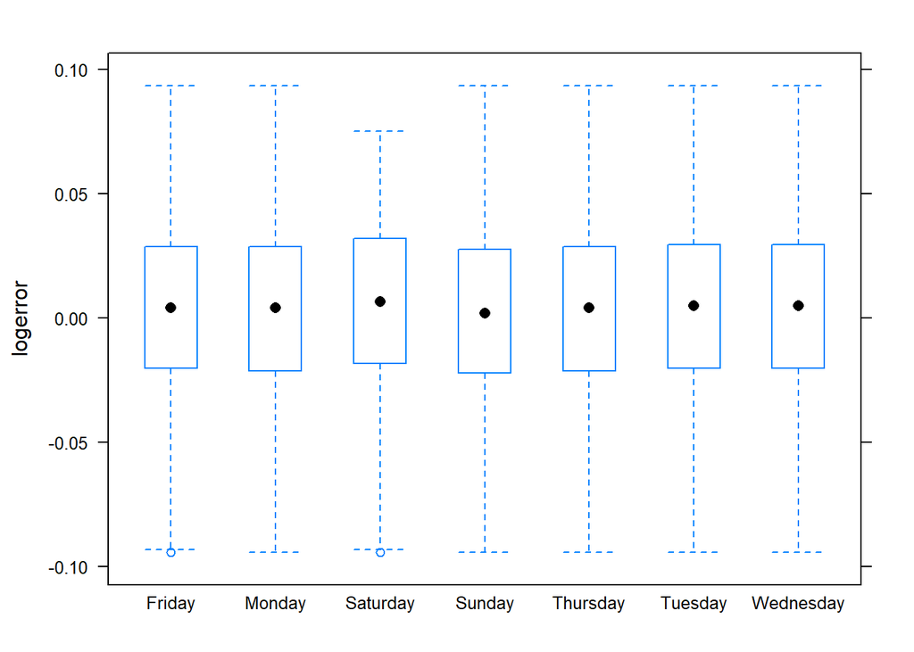

```r
library(tabplot)
bwplot(logerror ~ txn_weekday, data = subset(train, abs(logerror) < quantile(train$logerror,0.9)))
```

[figure not shown]

```r
tableplot(train, select = c('logerror', 'txn_weekday'), nbin=10)
```

### age of the house

```r
train$age<-(2017-train$build_year+1)
summary(train$age)
```

```
##    Min. 1st Qu.  Median    Mean 3rd Qu.    Max.    NA's
##    3.00   31.00   48.00   49.47   65.00  133.00     756
```

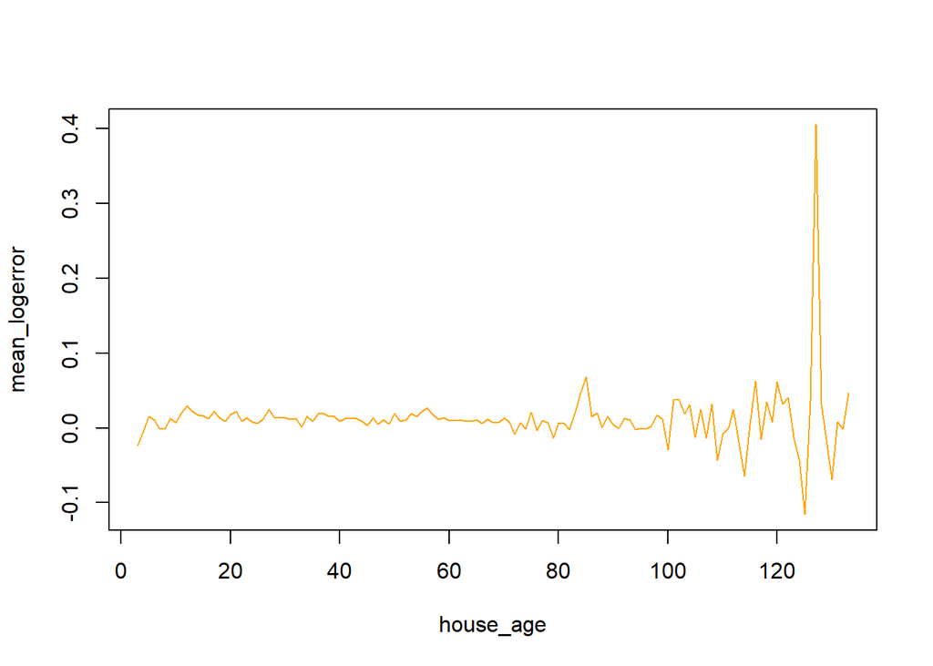

```r
err.age <- by(train, train$age, function(x) { return(mean(x$logerror))})
plot(names(err.age), err.age, type = 'l',xlab='house_age',ylab='mean_logerror', col='orange')
```

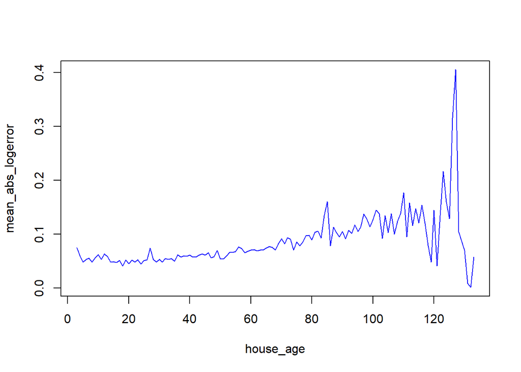

```r
err.age1 <- by(train, train$age, function(x) { return(mean(abs(x$logerror)))})
plot(names(err.age1), err.age1, type = 'l',xlab='house_age',ylab='mean_abs_logerror', col='blue')
```

The graph indicates that houses with more than 80 ages tend to have more non-zero logerror. As to the most recent house, the differences in average logerror and absolute logerror indicate that Zestimate tends to underestimate.

## Tax

### tax ratio

tax ratio = tax_property / tax_total

```r
train$tax_ratio <- (train$tax_property / train$tax_total)
summary(train$tax_ratio)
```

```
##      Min.   1st Qu.    Median      Mean   3rd Qu.      Max.      NA's
##   0.00020   0.01188   0.01261   0.01779   0.01424 109.50000         7
```

```r
nrow(subset(train,tax_ratio > 1))
```

```
## [1] 5
```

Tax ratio can not be over 100%. We can see that there are at least 5 observations are errors.

To seperate the right and error groups, and calculate correlations.

```r
with(subset(train, tax_ratio <= 1), cor(logerror, tax_property, use='pairwise.complete.obs'))
```

```
## [1] -0.006667033
```

```r
with(subset(train,tax_ratio <= 1) , cor(logerror, tax_ratio, use='pairwise.complete.obs'))
```

```
## [1] -0.05170073
```

```r
with(subset(train, tax_ratio <= 1), cor(abs(logerror), tax_property, use='pairwise.complete.obs'))
```

```
## [1] 0.0482841
```

```r
with(subset(train,tax_ratio <= 1) , cor(abs(logerror), tax_ratio, use='pairwise.complete.obs'))
```

```
## [1] 0.04542842
```

We can see that the correlation between logerror ad tax_ratio is much stronger than the tax_property, while the not big change with absolute logerror.

### tax of built structure/ total tax

```r
train$tax_ratiobuilt <- (train$tax_building / train$tax_total)
summary(train$tax_ratiobuilt)
```

```
##    Min. 1st Qu.  Median    Mean 3rd Qu.    Max.    NA's
##  0.0001  0.2973  0.4344  0.4517  0.6000  0.9990     380
```

```r
with(train, cor(logerror, tax_ratiobuilt, use = 'pairwise.complete.obs'))
```

```
## [1] 0.01648078
```

```r
with(train, cor(abs(logerror), tax_ratiobuilt, use = 'pairwise.complete.obs'))
```

```
## [1] -0.01367183
```

This may not be a good feature since the correlation is still low.

## Area

### lot_living

lot_living = area_lot / area_live_finished

```r
train$lot_living<- (train$area_lot / train$area_live_finished)
summary(train$lot_living)
```

```
##     Min.  1st Qu.   Median     Mean  3rd Qu.     Max.     NA's
##    0.087    3.245    4.683   23.330    7.063 5586.000    14466
```

```r
nrow(subset(train, lot_living < 1))
```

```
## [1] 806
```

Since lot area should always be bigger than the living area, the lot_living with number smaller than one must be errors.

To seperate the right and error groups, and calculate correlations.

```r
with(subset(train, lot_living >= 1), cor(logerror, area_lot, use='pairwise.complete.obs'))
```

```
## [1] 0.004528626
```

```r
with(subset(train, lot_living >= 1), cor(logerror, lot_living, use='pairwise.complete.obs'))
```

```
## [1] 0.007825395
```

```r
with(subset(train,lot_living >= 1) , cor(abs(logerror), area_lot, use='pairwise.complete.obs'))
```

```
## [1] 0.0004240236
```

```r
with(subset(train,lot_living >= 1) , cor(abs(logerror), lot_living, use='pairwise.complete.obs'))
```

```
## [1] 0.002303151
```

The correlation is stronger than only with log area.

## Room number

### bedroom/bathroom ratio

```r
train$bbratio<-(train$num_bedroom/(train$num_bathroom+1))
summary(train$bbratio)
```

```
##    Min. 1st Qu.  Median    Mean 3rd Qu.    Max.
##  0.0000  0.7500  1.0000  0.9537  1.0000  5.0000
```

```r
with(subset(train, num_room >= num_bedroom + num_bathroom), cor(logerror, num_bedroom, use = 'pairwise.complete.obs'))
```

```
## [1] 0.01828101
```

```r
with(subset(train, num_room >= num_bedroom + num_bathroom), cor(logerror, num_bathroom, use = 'pairwise.complete.obs'))
```

```
## [1] 0.01637253
```

```r
with(subset(train, num_room >= num_bedroom + num_bathroom), cor(logerror, bbratio, use = 'pairwise.complete.obs'))
```

```
## [1] 0.01197677
```

```r
with(subset(train, num_room >= num_bedroom + num_bathroom), cor(abs(logerror), num_bedroom, use = 'pairwise.complete.obs'))
```

```
## [1] -0.1071467
```

```r
with(subset(train, num_room >= num_bedroom + num_bathroom), cor(abs(logerror), num_bathroom, use = 'pairwise.complete.obs'))
```

```
## [1] -0.08263535
```

```r
with(subset(train, num_room >= num_bedroom + num_bathroom), cor(abs(logerror), bbratio, use = 'pairwise.complete.obs'))
```

```
## [1] -0.0996913
```

## Location

### latitude - longitude

```r
train$location_ll<- (train$latitude * train$longitude)
train$location_22<- (train$latitude - train$longitude)

with(train, cor(logerror, latitude, use = 'pairwise.complete.obs'))
```

```
## [1] 0.004915466
```

```r
with(train, cor(logerror, longitude, use = 'pairwise.complete.obs'))
```

```
## [1] -0.003432217
```

```r
with(train, cor(logerror, location_ll, use = 'pairwise.complete.obs'))
```

```
## [1] -0.00493464
```

```r
with(train, cor(logerror, location_22, use = 'pairwise.complete.obs'))
```

```
## [1] 0.004534658
```

```r
with(train, cor(abs(logerror), latitude, use = 'pairwise.complete.obs'))
```

```
## [1] 0.0191675
```

```r
with(train, cor(abs(logerror), longitude, use = 'pairwise.complete.obs'))
```

```
## [1] -0.03625613
```

```r
with(train, cor(abs(logerror), location_ll, use = 'pairwise.complete.obs'))
```

```
## [1] -0.02612986
```

```r
with(train, cor(abs(logerror), location_22, use = 'pairwise.complete.obs'))
```

```
## [1] 0.03240693
```

### draw the region map

```r
sample(train$region_city,5)
```

```
## [1] "34278" "33836" "12292" "12447" "13150"
```

```r
library(leaflet)
```

```r
train$abs_logerror <- (abs(train$logerror))

# map on large abs_logerr
lower = quantile(train$abs_logerror, 0.1)
upper = quantile(train$abs_logerror, 0.9)

well_estimate = train[((train$abs_logerror < upper) & (train$abs_logerror > lower)),
                      c("longitude", "latitude", "abs_logerror")]
bad_estimate = train[((train$abs_logerror > upper) | (train$abs_logerror < lower)),
                     c("longitude", "latitude", "abs_logerror")]


over_est = quantile(train$logerror, 0.99)
over_estimate = train[(train$logerror > upper),
                      c("longitude", "latitude", "logerror")]
over_estimate$type = "over"

under_est = quantile(train$logerror, 0.01)
under_estimate = train[(train$abs_logerror < lower),
                     c("longitude", "latitude", "logerror")]
under_estimate$type = "under"

pal <- colorFactor(c("red","navy"), domain = c("over", "under"))

rbind(over_estimate, under_estimate) %>%
leaflet() %>%
  addTiles() %>%
  addCircleMarkers(lng=~longitude/10e5,
             lat=~latitude/10e5,
             color = ~pal(type),
             radius = 3,
             stroke = FALSE, fillOpacity = 0.3)
```

[interactive chart not shown]

```r
mapRegion = function(X, ub, lb){

  over_est = quantile(train$logerror, ub)
  over_estimate = X[(X$logerror > over_est),
                        c("longitude", "latitude", "logerror")]
  over_estimate$type = "over"

  under_est = quantile(train$logerror, lb)
  under_estimate = X[(X$abs_logerror < under_est),
                         c("longitude", "latitude", "logerror")]
  under_estimate$type = "under"

  pal <- colorFactor(c("red", "navy"), domain = c("over", "under"))

  rbind(over_estimate, under_estimate) %>%
    leaflet() %>%
    addTiles() %>%
    addCircleMarkers(lng=~longitude/10e5,
                     lat=~latitude/10e5,
                     color = ~pal(type),
                     radius = 5,
                     stroke = FALSE, fillOpacity = 0.5)
}

region = train[!is.na(train$region_city)&(train$region_city == "52842"),]
mapRegion(region, 0.9, 0.5)
```

[interactive chart not shown]

We can input the region_city codes to check the house price prediction in certain cities. For example, for city with code “52842”, most of the houses are along the beach. We can see that they are tend to be overestimated here.